# HW4-Predictive regression modeling with R

misken

February 9, 2018

## Step 1 - Familiarize yourself with the data and the assignment

In this assignment you'll build some predictive regression models with R on a dataset containing inpatient discharges from hospitals in New York.

The version of this data that we'll be using is from a Kaggle dataset. See https://www.kaggle.com/jonasalmeida/2015-deidentified-ny-inpatient-discharge-sparcs. Unfortunately, the column metadata wasn't posted. However, since this is a publicly available dataset, we can visit the source at https://health.data.ny.gov/Health/Hospital-Inpatient-Discharges-SPARCS-De-Identified/82xm-y6g8.

If you scroll down on that page you'll find descriptions of the columns (click the little Show All link to display the entire list).

Most of the fields are self-explanatory. You'll notice that there are several sets of diagnosis and procedure codes. A few definitions are helpful.

### DRG - Diagnosis Related Groups

DRGs are a coding system developed in the 1980s that form the basis of how hospitals are reimbursed from Medicare (US Govt) or private insurers. After a patient is discharged from the hospital, a program known as a *DRG grouper* uses information such as diagnosis and procedure codes (ICD-9-CM) to assign a DRG to the patient. A full list of the over 900 DRGs can be found at:

https://www.cms.gov/Research-Statistics-Data-and-Systems/Statistics-Trends-and-Reports/MedicareFeeforSvcPartsAB/downloads/DRGdesc08.pdf

In that list you'll see that MDC (Medical Diagnostic Category) is simply a grouping of DRGs.

### CCS - Clinical Classification System

The [CCS](https://www.hcup-us.ahrq.gov/toolssoftware/ccs/ccs.jsp) system was developed by the [Agency for Healthcare Research and Quality (AHRQ)](https://www.ahrq.gov/) to provide a classification system better suited to healthcare research. There are CCS diagnosis codes and CCS procedure codes. From their website:

> The Clinical Classifications Software (CCS) for ICD-9-CM is a diagnosis and procedure categorization scheme that can be employed in many types of projects analyzing data on diagnoses and procedures. CCS is based on the International Classification of Diseases, 9th Revision, Clinical Modification (ICD-9-CM), a uniform and standardized coding system. The ICD-9-CM's multitude of codes - over 14,000 diagnosis codes and 3,900 procedure codes - are collapsed into a smaller number of clinically meaningful categories that are sometimes more useful for presenting descriptive statistics than are individual ICD-9-CM codes.

As we did in class, you'll be creating an R Markdown document to do the analysis as well as to document the steps you did (and answer some questions I'll throw at you).

You'll notice a few "Hacker Extra" tasks thrown in. These are for those of you who want to go a little above and beyond and attempt some more challenging tasks.

## Step 2 - Create a new R Markdown document

Save this file as a new R Markdown document and name it something that includes your last name in the filename. Save it into the same folder as this file.

## Step 3 - Create project and load data

Create an R Studio project in the current folder (the one containing this file). You'll notice that there is a folder named **data**. Inside of it you'll find the data file for this assignment:

- **ipd_resp.RData**

The full dataset contains over two million records and is available as a CSV file from Kaggle. I did a little data filtering and cleaning to create a subset to use for this regression assignment. Specifically, I did the following:

- used dplyr to filter records so that we were just working with `APR MDC Code` == 4. These are patients having respiratory related diagnoses.
- a bunch of fields were read in as `chr` and I changed them to factors using `as.factor`.
- There were some fields we don't need and they were dropped.
- Just as in HW1, I cleaned up the charges and costs fields that got interpreted as `chr` because of the leading dollar sign. Now they are numeric.
- Modified some field names to make them easier to work with.

See the data prep script for all the details. You do **NOT** need to run the data prep script. I'm just including it so you can see a typical data prep script.

### Load the data

```r
load("./data/ipd_resp.RData")
#str(ipd_resp)
```

## Step 4 - Partition into training and test sets

Just run this chunk to create training and test datasets. This way we'll all be working with the same datasets. Notice that the test set is 30% of the full dataset.

```r
set.seed(1828)
sample_size <- ceiling(0.30 * nrow(ipd_resp))
testrecs <- sample(nrow(ipd_resp),sample_size)
ipd_test <- ipd_resp[testrecs,]
ipd_train <- ipd_resp[-testrecs,]  # Negative in front of vector means "not in"
rm(ipd_resp) # No sense keeping a copy of the entire dataset around
```

## Step 5 - EDA on training data

Now start with some EDA on the training dataset`ipd_train`. The test data will only get used after building models and want to compare their predictive abilities.

You'll notice that `ipd_train` contains a few numeric fields and many factors (categorical data). You are free to use any of these fields in your regression models to predict `Total_Charges`.

Start by using things like ggplot2 and dplyr to explore the training dataset. You can use other packages as well. Your goal is to gain a general understanding of the variables and perhaps uncover some useful relationships that you can use in your regression models.

**NOTE: In the data prep phase I made sure there were no NA values in the data frames that we are using for this assignment. So, no need to worry about that.**

```r
library(dplyr)
```

```r
library(ggplot2)
library(boot)
library(reshape2)
```

```r
summary(ipd_train)
```

```
##      Health_Service_Area  Hospital_County   Facility_Id
##  New York City :59355    Manhattan:17112   1169   :  3769
##  Long Island   :18906    Kings    :14286   1464   :  2655
##  Hudson Valley :14989    Bronx    :13883   1172   :  2517
##  Capital/Adiron:11629    Queens   :10931   1178   :  2341
##  Central NY    :10770    Suffolk  : 9603   1458   :  2091
##  Western NY    :10456    Nassau   : 9303   413    :  2013
##  (Other)       :11215    (Other)  :62202   (Other):121934
##                                                         Facility_Name
##  Montefiore Medical Center - Henry & Lucy Moses Div            :  3769
##  New York Presbyterian Hospital - Columbia Presbyterian Center :  2655
##  Lincoln Medical & Mental Health Center                        :  2517
##  Bronx-Lebanon Hospital Center - Concourse Division            :  2341
##  New York Presbyterian Hospital - New York Weill Cornell Center:  2091
##  Good Samaritan Hospital Medical Center                        :  2013
##  (Other)                                                       :121934
##        Age_Group        ZipCode      Gender
##  0 to 17    :18955   112    :16184   F:72465
##  18 to 29   : 4410   104    :15118   M:64855
##  30 to 49   :13174   117    :10422   U:    0
##  50 to 69   :44726   100    : 8879
##  70 or Older:56055   113    : 6190
##                      115    : 4771
##                      (Other):75756
##                      Race                   Ethnicity
##  Black/African American:26759   Multi-ethnic     :   533
##  Multi-racial          : 1248   Not Span/Hispanic:114997
##  Other Race            :28283   Spanish/Hispanic : 16107
##  White                 :81030   Unknown          :  5683
##
##
##
##  Length_of_Stay        Type_of_Admission
##  Min.   :  1.000   Elective     :  7833
##  1st Qu.:  2.000   Emergency    :123327
##  Median :  4.000   Newborn      :    15
##  Mean   :  5.591   Not Available:    56
##  3rd Qu.:  7.000   Trauma       :   391
##  Max.   :119.000   Urgent       :  5698
##
```

[output cut: 41 more lines]

```
##  Extreme :14310               Extreme : 9920
##  Major   :46752               Major   :36936
##  Minor   :23375               Minor   :50734
##  Moderate:52883               Moderate:39730
##  unknown :    0
##
##
##                  Payment_Typology_1 Total_Charges      Total_Costs
##  Medicare                 :72837    Min.   :      1   Min.   :     0.6
##  Medicaid                 :34848    1st Qu.:  13190   1st Qu.:  5283.6
##  Private Health Insurance :12315    Median :  24485   Median :  8998.8
##  Blue Cross/Blue Shield   :10478    Mean   :  41551   Mean   : 15527.7
##  Self-Pay                 : 3150    3rd Qu.:  46436   3rd Qu.: 16499.2
##  Managed Care, Unspecified: 1292    Max.   :2691248   Max.   :689872.8
##  (Other)                  : 2400
```

Now, it's your turn ...

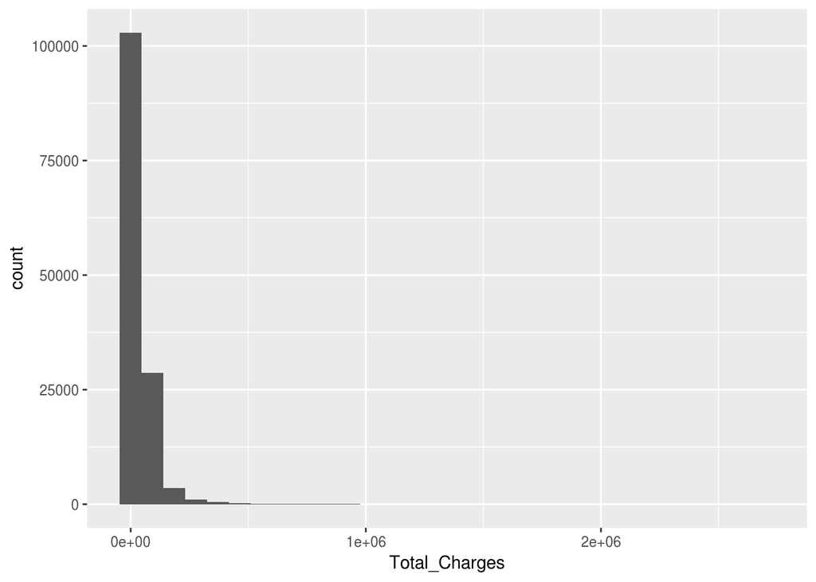

```r
ipd_train %>%
  ggplot(aes(Total_Charges)) + geom_histogram()
```

> Here is a histogram of Total_Charges. It is skewed to the right.

```r
ipd_train %>%
  group_by(Severity_of_Illness = APR_Severity_of_Illness_Desc) %>%
  summarize(Total_Charges = mean(Total_Charges)) %>%
  arrange(-Total_Charges)
```

```
## # A tibble: 4 x 2
##   Severity_of_Illness Total_Charges
##                <fctr>         <dbl>
## 1             Extreme     112670.85
## 2               Major      46032.92
## 3            Moderate      28014.39
## 4               Minor      19674.41
```

> As suspected, the more severe the illness, the higher the average total charge is. This could be useful going forward.

```r
ipd_train %>%
  group_by(Risk_of_Mortality = APR_Risk_of_Mortality) %>%
  summarize(Total_Charges = mean(Total_Charges)) %>%
  arrange(-Total_Charges)
```

```
## # A tibble: 4 x 2
##   Risk_of_Mortality Total_Charges
##              <fctr>         <dbl>
## 1           Extreme     109819.50
## 2             Major      53338.67
## 3          Moderate      34987.59
## 4             Minor      24761.33
```

> Intuitively, risk of mortality and severity of the illness would seem to be highly related, so it's no surpise that the greater the risk of mortality results in higher average total charges.

```r
ipd_train %>%
  group_by(Age_Group = Age_Group) %>%
  summarize(Total_Charges = mean(Total_Charges)) %>%
  arrange(-Total_Charges)
```

```
## # A tibble: 5 x 2
##     Age_Group Total_Charges
##         <ord>         <dbl>
## 1 70 or Older      44542.24
## 2    50 to 69      44051.45
## 3    18 to 29      41513.02
## 4    30 to 49      38783.43
## 5     0 to 17      28739.61
```

> This is interesting. At first it seems as though this would follow the same pattern of higher average total charges for higher age group; however, 18 to 29 and 30 to 49 are flipped. Additionally, there is hardly any difference between 70 or Older and 50 to 69. The results of this analysis are less obvious.

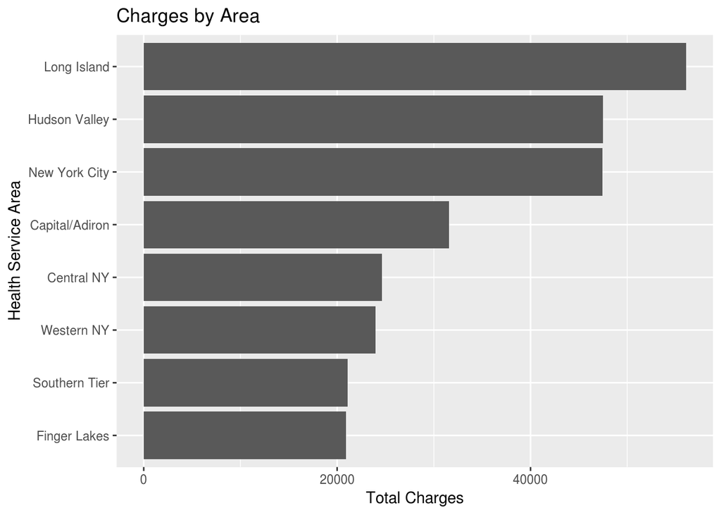

```r
ipd_train %>%
  group_by(Health_Service_Area) %>%
  summarize(Total_Charges = mean(Total_Charges)) %>%
  ggplot(aes(x = reorder(Health_Service_Area, Total_Charges), Total_Charges)) +
  geom_col() + coord_flip() + labs(title = "Charges by Area",
                                   x = "Health Service Area",
                                   y = "Total Charges")
```

> Here is total charges by health service area. This could come into play in a regression model.

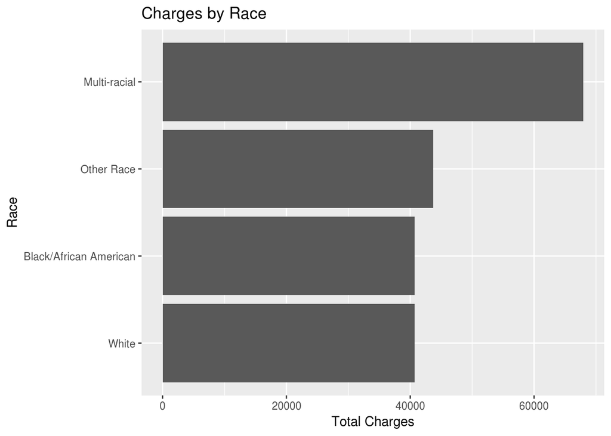

```r
ipd_train %>%
  group_by(Race) %>%
  summarize(Total_Charges = mean(Total_Charges)) %>%
  ggplot(aes(x = reorder(Race, Total_Charges), Total_Charges)) +
  geom_col() + coord_flip() + labs(title = "Charges by Race",
                                   x = "Race",
                                   y = "Total Charges")
```

> Here is total charges by race. There does not seem to be a huge difference, except for the multi-racial group.

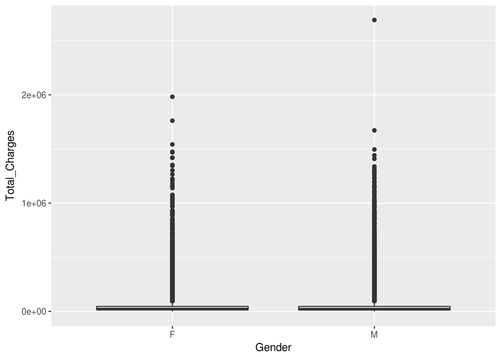

```r
ggplot(ipd_train,
       aes(Gender, Total_Charges)) + geom_boxplot()
```

> The above boxplots seem to indicate that there is not much variance in total charges by gender.

```r
cor(ipd_train[,c(10,24)])
```

```
##                Length_of_Stay Total_Charges
## Length_of_Stay      1.0000000     0.7874142
## Total_Charges       0.7874142     1.0000000
```

> A correlation matrix of total charges and length of stay suggests a strong positive correlation between the two.

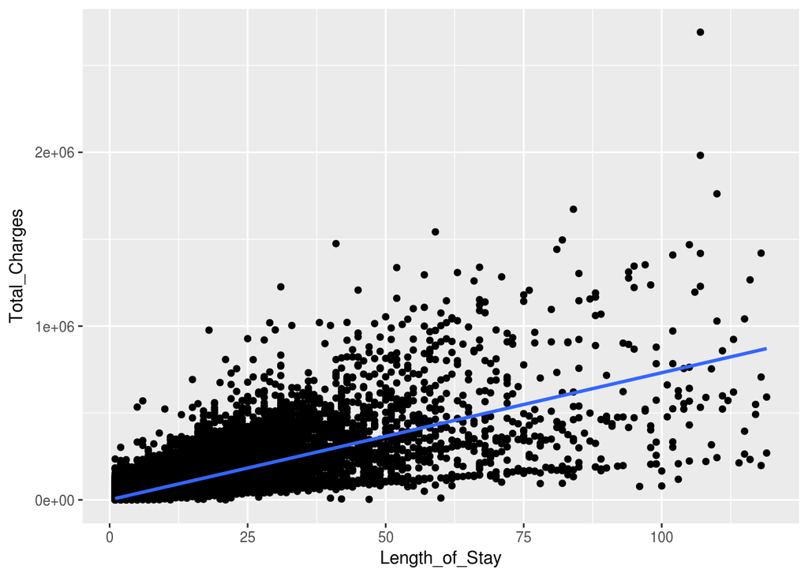

```r
ipd_train %>%
  ggplot(aes(Length_of_Stay, Total_Charges)) + geom_point() + geom_smooth(method = "lm")
```

> Here is a visualization of the correlation matrix presented above.

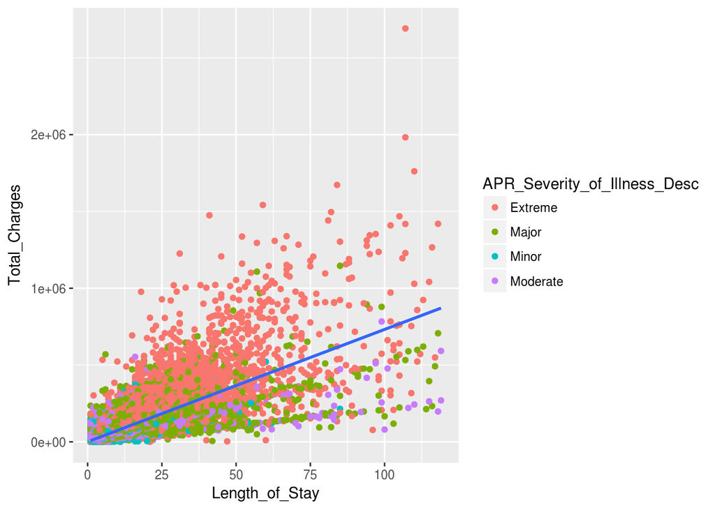

```r
ipd_train %>%
  ggplot(aes(Length_of_Stay, Total_Charges)) + geom_point(aes(color = APR_Severity_of_Illness_Desc)) + geom_smooth(method = "lm")
```

> Now looking at length of stay and total charges, it appears that more severe illnesses tend to lead to higher total charges.

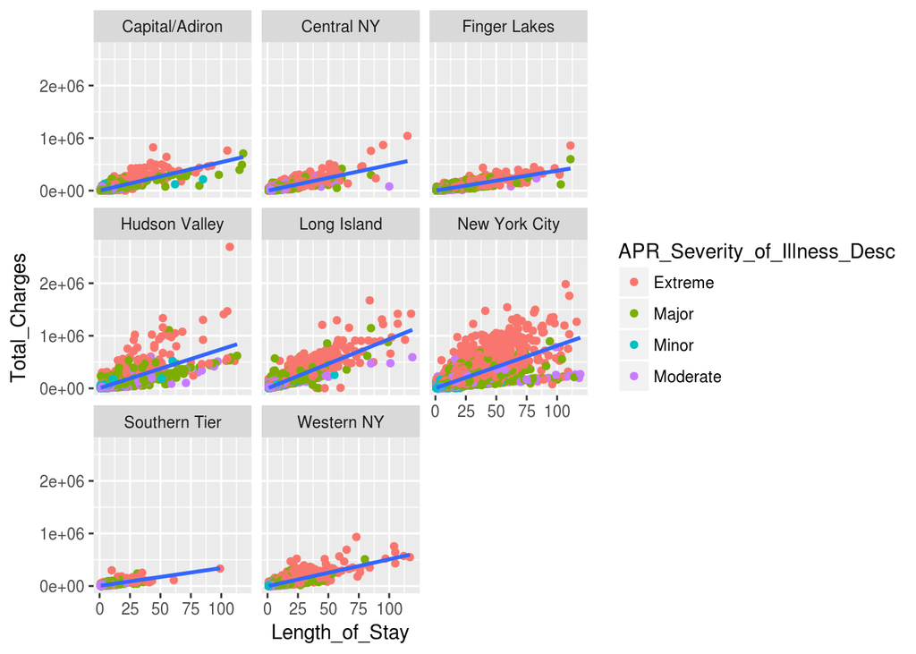

```r
ipd_train %>%
  ggplot(aes(Length_of_Stay, Total_Charges)) + geom_point(aes(color = APR_Severity_of_Illness_Desc)) + geom_smooth(method = "lm") + facet_wrap(~Health_Service_Area)
```

> Now the plot is faceted by health service area. Some of the graphs, such as Long Island and New York City, appear to have noticeably higher charges. Other areas look very similar. It may be useful to drill down from health service area to hospital county in the regression model.

## Step 6 - Building and evaluation of predictive models

Now that you know a little more about the data, it's time to start building a few predictive models for `Total_Charges`. The error metric that we will use to evaluate the models (both for fit and for predictions) is **median absolute deviation** (MAD). This is nothing more than the median of the absolute value of the residuals for a fitted model.

**QUESTION:** What might be an advantage of using median absolute deviation instead of mean absolute deviation?

> The advantage of using median absolute deviation over mean absolute deviation is that the effect of extreme values is negated. Medians are resistant to outliers, and one or two outliers can dominate a mean. The data set may be relatively consistent but with a few very large/small values. This will result in a larger error metric that will not reflect the relative stability of the data. This is not the case with medians, where the stability would be shown in the error metric.

Obviously we want models with lower MAD values. Our ultimate goal is to create a model that predicts well on the test dataset, `ipd_test`.

### Null model

It's always a good idea to start out with what we call the *null model*. This is the simplest possible model and one that other models better be able to beat. For this regression problem, the null model is simply a regression model that just has a y-intercept. If you remember some of your statistics, you won't be surprised that the best fit value for the y-intercept in this case is the mean of the response variable, `Total_Charges`.

```r
charges_lm0 <- lm(Total_Charges ~ 1, data = ipd_train)
summary(charges_lm0)
```

```
##
## Call:
## lm(formula = Total_Charges ~ 1, data = ipd_train)
##
## Residuals:
##     Min      1Q  Median      3Q     Max
##  -41550  -28361  -17067    4885 2649697
##
## Coefficients:
##             Estimate Std. Error t value Pr(>|t|)
## (Intercept)    41551        172   241.5   <2e-16 ***
## ---
## Signif. codes:  0 '***' 0.001 '**' 0.01 '*' 0.05 '.' 0.1 ' ' 1
##
## Residual standard error: 63750 on 137319 degrees of freedom
```

```r
# Compute the MAD value
median(abs(charges_lm0$residuals))
```

```
## [1] 24376.3
```

It's not hard to create regression models with smaller MAD values than this. :)

Just to give you a benchmark, I built a model on the training set that had a MAD value of 7270.340. Again, this is just the median of the absolute values of the residuals of the fitted model. Later when I used this model on the test data, I got a MAD of ... well, I'll tell you a little later.

### Model building

Using the information you've gained from reading about the data and doing some EDA, build several regression models and compute the MAD from each. Summarize your results in terms of which model or models appear to fit well.

Identify your top 3 models in terms of lowest MAD values to use in the next part in which you'll use them to make predictions on the test dataset.

```r
# Regression models
charges_lm1 = glm(Total_Charges ~ Length_of_Stay + Health_Service_Area, data = ipd_train)
charges_lm2 = glm(Total_Charges ~ Length_of_Stay + Hospital_County, data = ipd_train)
charges_lm3 = glm(Total_Charges ~ Length_of_Stay * Hospital_County, data = ipd_train)
charges_lm4 = glm(Total_Charges ~ Length_of_Stay : Hospital_County, data = ipd_train)
charges_lm5 = glm(Total_Charges ~ Length_of_Stay : Hospital_County + APR_Risk_of_Mortality + APR_Severity_of_Illness_Desc, data = ipd_train)
charges_lm6 = glm(Total_Charges ~ Length_of_Stay : Hospital_County + APR_Risk_of_Mortality : APR_Severity_of_Illness_Desc, data = ipd_train)

# Compute the MAD value
median(abs(charges_lm1$residuals))
```

```
## [1] 9770.393
```

```r
median(abs(charges_lm2$residuals))
```

```
## [1] 9414.383
```

```r
median(abs(charges_lm3$residuals))
```

```
## [1] 6871.578
```

```r
median(abs(charges_lm4$residuals))
```

```
## [1] 6761.079
```

```r
median(abs(charges_lm5$residuals))
```

```
## [1] 6435.788
```

```r
median(abs(charges_lm6$residuals))
```

```
## [1] 6366.714
```

> Essentially I started on the assumption that length of stay and location would be correlated to total charges and added on from there. Hospital service area was too broad so hospital county was more significant. Then I tested out the interaction between the two variables. Ultimately I added the severity of illness and risk of mortality to the model and then tested out the interaction between the two, since they would seem to be related. My top 3 models in terms of lowest MAD involve the interaction effects of length of stay and hospital county, with two of them including some form of the risk of mortality and severity of illness. They are: **charges_lm4**, **charges_lm5**, and **charges_lm6**.

**HACKER EXTRA:** Use k-crossfold validation to select your top 3 models.

```r
charges_cv1 = cv.glm(ipd_train, charges_lm1, K = 5)
charges_cv2 = cv.glm(ipd_train, charges_lm2, K = 5)
charges_cv3 = cv.glm(ipd_train, charges_lm3, K = 5)
charges_cv4 = cv.glm(ipd_train, charges_lm4, K = 5)
charges_cv5 = cv.glm(ipd_train, charges_lm5, K = 5)
charges_cv6 = cv.glm(ipd_train, charges_lm6, K = 5)
cvResults <- as.data.frame(rbind(charges_cv1$delta,charges_cv2$delta,
                                 charges_cv3$delta,charges_cv4$delta,
                                 charges_cv5$delta,charges_cv6$delta))
names(cvResults) <- c("MSE", "MSE_Adjusted")
cvResults$Model <- sprintf("charges_lm%s", 1:6)
cvResults
```

```
##          MSE MSE_Adjusted       Model
## 1 1429816548   1429753991 charges_lm1
## 2 1383105438   1382807079 charges_lm2
## 3 1209264355   1208012843 charges_lm3
## 4 1221028351   1219686806 charges_lm4
## 5 1166243879   1165495175 charges_lm5
## 6 1166678705   1165746773 charges_lm6
```

> Using k-crossfold validation, the results are almost the same. The only difference is that charges_lm3 replaces charges_lm4 in the top 3 models. For the purpose of this homework assignment, I will choose my models based on the MAD, so my top 3 models are still **charges_lm4**, **charges_lm5**, and **charges_lm6**.

### Model diagnostics

#### Scatterplots of actual vs fitted values

For your top 3 models, create a scatter plot showing actual vs fitted values of `Total_Charges`. Remember, it's often nice to "gather up" your results into a data frame to facilitate plotting. See the notes on comparing competing regression models. Here's what one of my scatterplots looks like.

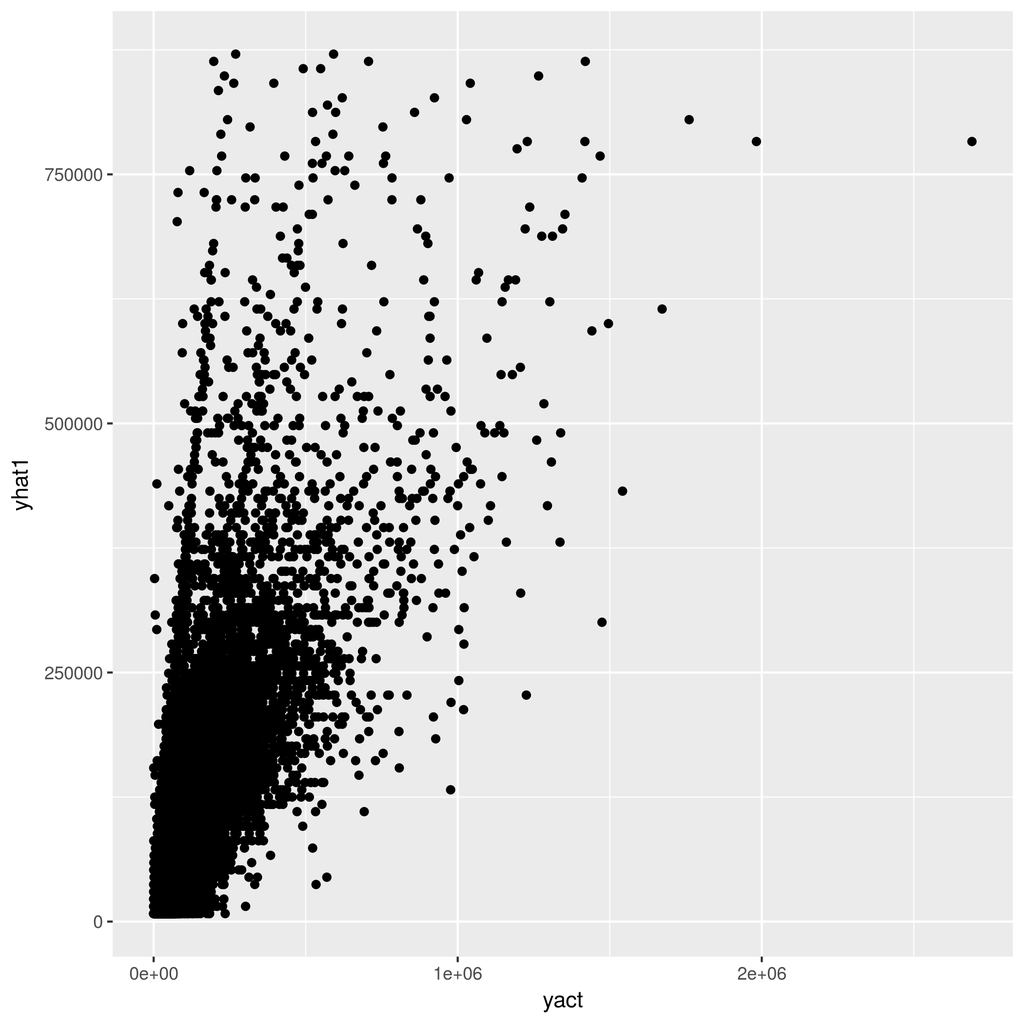

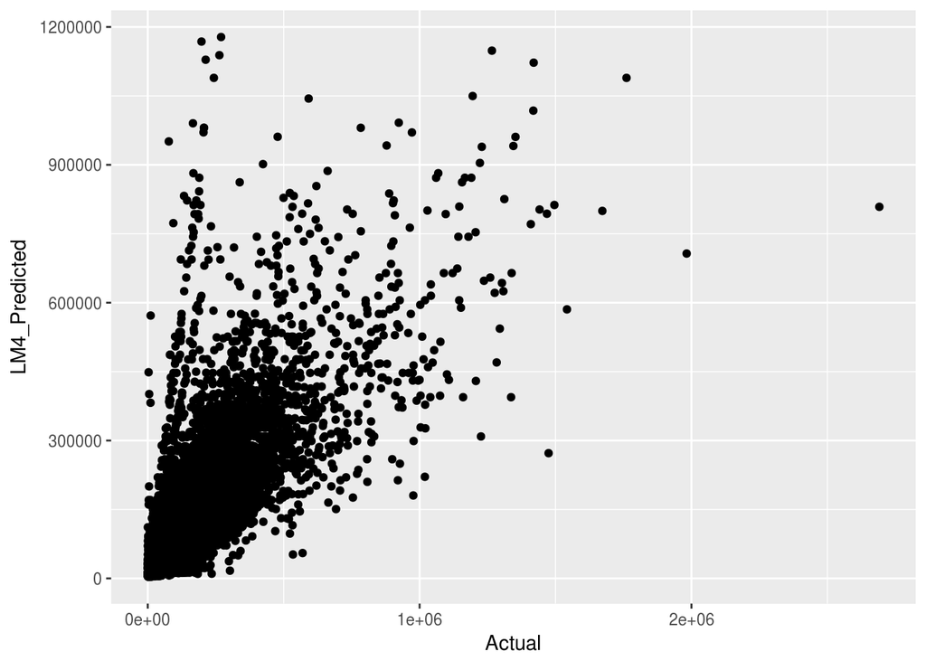

```r
modelTests <- data.frame(Actual = ipd_train$Total_Charges,
                         LM4_Predicted = charges_lm4$fitted.values,
                         LM5_Predicted = charges_lm5$fitted.values,
                         LM6_Predicted = charges_lm6$fitted.values)

ggplot(modelTests, aes(Actual,LM4_Predicted)) + geom_point()
```

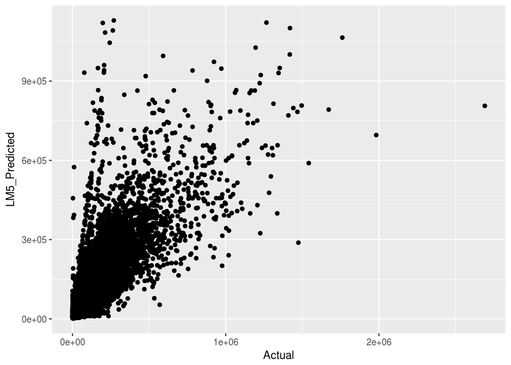

```r
ggplot(modelTests, aes(Actual,LM5_Predicted)) + geom_point()
```

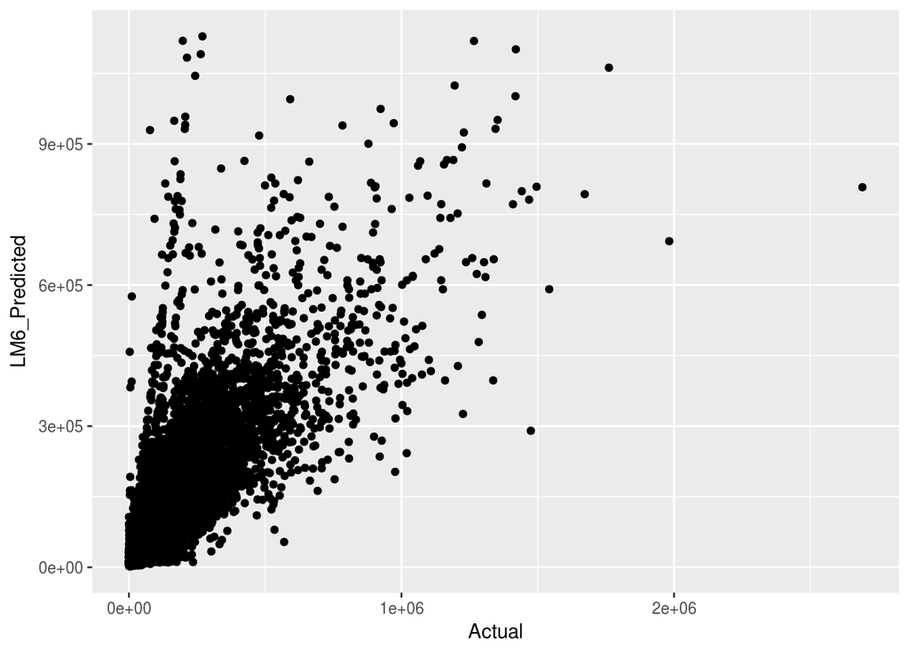

```r
ggplot(modelTests, aes(Actual,LM6_Predicted)) + geom_point()
```

#### Normality of residuals

Create a histogram of the residuals for your top 3 models. You may have to tweak the axes scales to make a nice histogram.

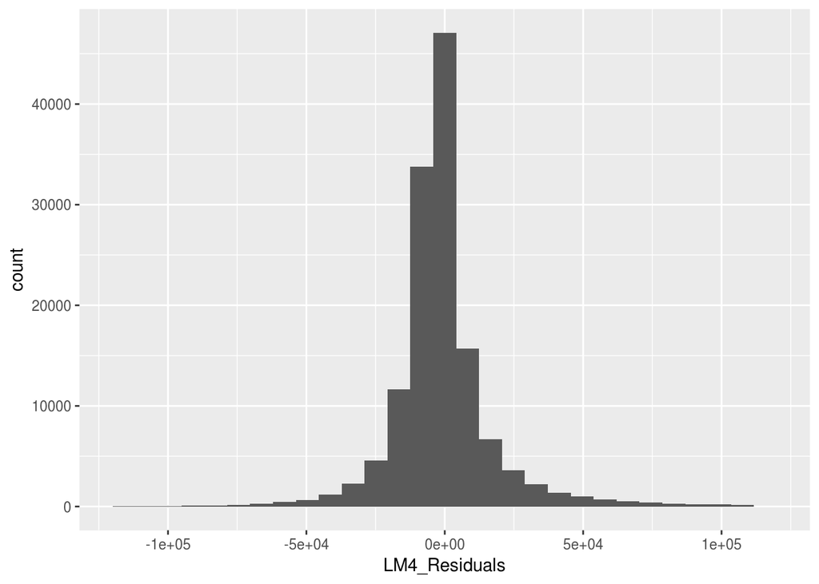

```r
modelResiduals <- data.frame(LM4_Residuals = charges_lm4$residuals,
                         LM5_Residuals = charges_lm5$residuals,
                         LM6_Residuals = charges_lm6$residuals)

ggplot(modelResiduals, aes(LM4_Residuals)) + geom_histogram() + xlim(-120000,120000)
```

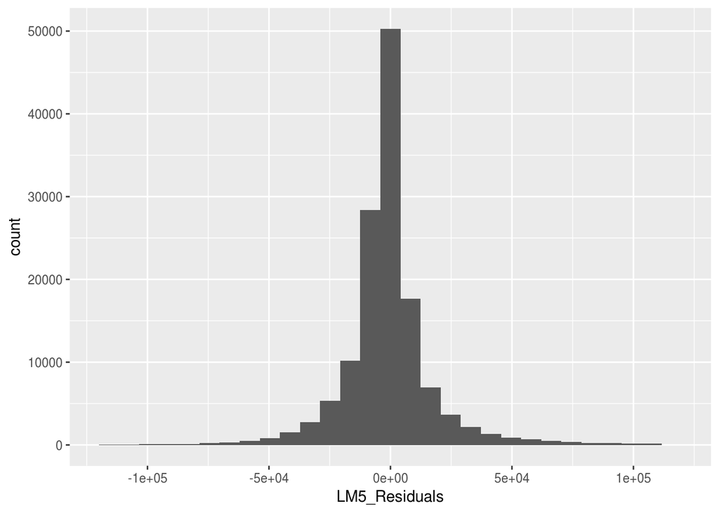

```r
ggplot(modelResiduals, aes(LM5_Residuals)) + geom_histogram() + xlim(-120000,120000)
```

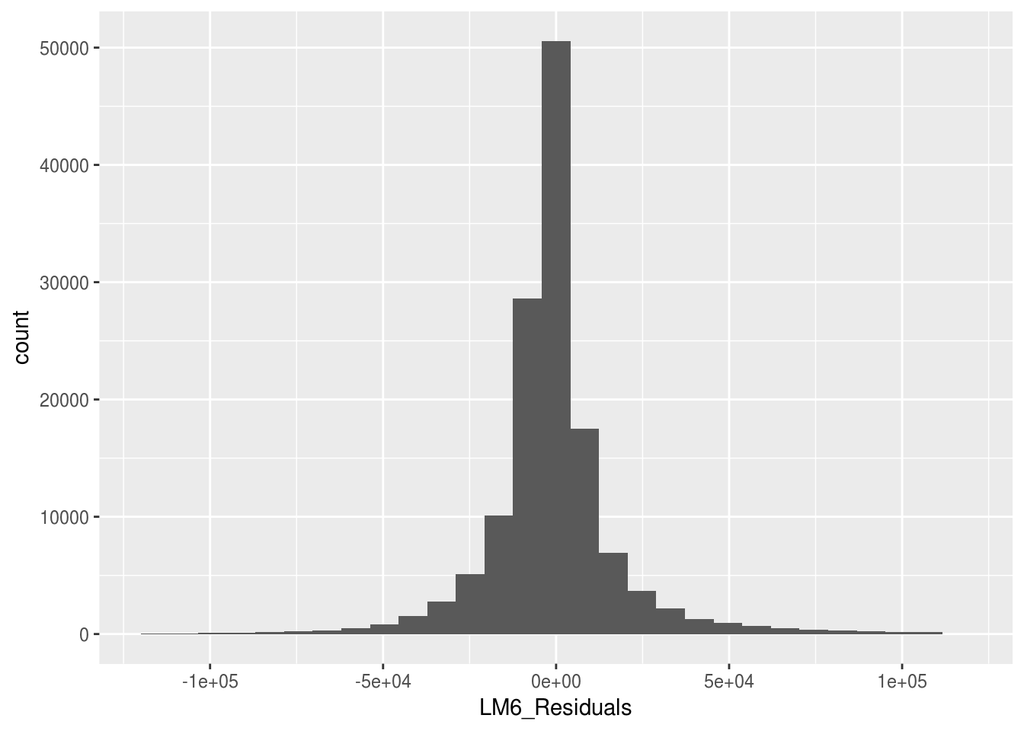

```r
ggplot(modelResiduals, aes(LM6_Residuals)) + geom_histogram() + xlim(-120000,120000)
```

#### Constant variance

Make an appropriate plot to check for constant variance (homeskedasticity) for your top model. Don't remember what kind of plot to make? See my notes on residual analysis or any intro stats book.

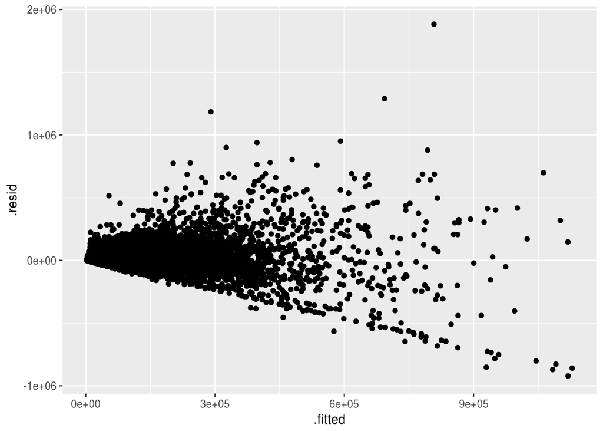

```r
ggplot(charges_lm6, aes(x = .fitted, y = .resid)) + geom_point()
```

> The outward funnel shape of the graph shows that the model is heteroskedastic. The assumption of equal variance is not true for all fitted values. The model is more volatile for higher fitted values.

### Make predictions for the test dataset

For each of your top 3 models, make predictions for `ipd_test`.

```r
charges_predict_lm4 <- predict(charges_lm4, newdata=ipd_test, se.fit=TRUE,
                         interval="prediction", level=0.95)
charges_predict_lm5 <- predict(charges_lm5, newdata=ipd_test, se.fit=TRUE,
                         interval="prediction", level=0.95)
charges_predict_lm6 <- predict(charges_lm6, newdata=ipd_test, se.fit=TRUE,
                         interval="prediction", level=0.95)
```

### Evaluate the predictions

Compute the MAD for each of the three models' predictions on the test data.

HINT: Obviously you can't use the residuals (or errors) directly but will have to compute them. They are simply the difference between the actual values and your predicted values.

So, for the model I mentioned earlier that had a MAD of 7270.340 for the training data, the MAD on the test data was 7335.559. Notice that MAD for test is higher than MAD for train.

```r
median(abs(ipd_test$Total_Charges - charges_predict_lm4$fit))
```

```
## [1] 6827.367
```

```r
median(abs(ipd_test$Total_Charges - charges_predict_lm5$fit))
```

```
## [1] 6504.425
```

```r
median(abs(ipd_test$Total_Charges - charges_predict_lm6$fit))
```

```
## [1] 6466.962
```

**QUESTION:** Do you think it's typical that MAD for test would be higher than MAD for train? Why or why not?

> It is typical that MAD for test is higher than MAD for train because the model is fitted to the training data, while the model is predicting the test data. It is very easy to build a model that fits a data set, the hard part is making one that predicts new data. The model has never seen the test data and has not been fitted to it, so it would hold that the error metric, in this case MAD, is higher.

**QUESTION:** Which of your top 3 models had the lowest MAD for the test data?

> The model charges_lm6 had the lowest MAD for the test data at **6466.962**. This model also had the lowest MAD for the training data at **6366.714**.

**QUESTION:** How do the MAD values for the test data compare to the MAD values for the training data?

> The MAD values for all three of the models are higher for the test data than for the train. It is not by a lot, but they are higher. See the below plot for details.

Finally, create some sort of plot which shows the MAD values for both train and test for your top 3 models. One plot.

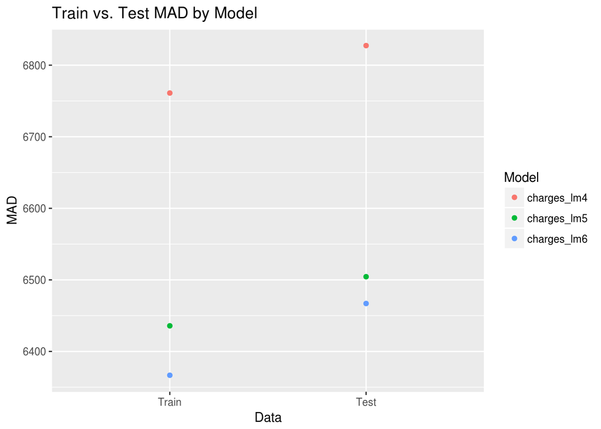

```r
testMAD <- rbind(median(abs(ipd_test$Total_Charges - charges_predict_lm4$fit)),
median(abs(ipd_test$Total_Charges - charges_predict_lm5$fit)),
median(abs(ipd_test$Total_Charges - charges_predict_lm6$fit)))

trainMAD <- rbind(median(abs(charges_lm4$residuals)),
                  median(abs(charges_lm5$residuals)),
                  median(abs(charges_lm6$residuals)))

lmMAD <- as.data.frame(cbind(trainMAD,testMAD))
names(lmMAD) <- c("Train", "Test")
lmMAD$Model <- sprintf("charges_lm%s", 4:6)
lmMAD_2 <- melt(lmMAD, id.vars = "Model", variable.name = "Data", value.name = "MAD")

lmMAD_2 %>%
  ggplot(aes(Data, MAD)) + geom_point(aes(color = Model)) + labs(title = "Train vs. Test MAD by Model")
```

### Your top model

Show your top performing model and discuss whether the model appears to make sense in terms of the variables included. Why did you choose the variables you did?

It will be interesting to compare the best models that everyone finds.

Later we'll learn more techniques that will likely allow us to beat simple linear models.

```r
charges_lm6
```

```
##
## Call:  glm(formula = Total_Charges ~ Length_of_Stay:Hospital_County +
##     APR_Risk_of_Mortality:APR_Severity_of_Illness_Desc, data = ipd_train)
##
## Coefficients:
##                                                        (Intercept)
##                                                            1639.94
##                               Length_of_Stay:Hospital_CountyAlbany
##                                                            6161.16
##                             Length_of_Stay:Hospital_CountyAllegany
##                                                            2884.35
##                                Length_of_Stay:Hospital_CountyBronx
##                                                            6289.98
##                               Length_of_Stay:Hospital_CountyBroome
##                                                            2858.49
##                          Length_of_Stay:Hospital_CountyCattaraugus
##                                                            3031.77
##                               Length_of_Stay:Hospital_CountyCayuga
##                                                            2596.74
##                           Length_of_Stay:Hospital_CountyChautauqua
##                                                            2297.94
##                              Length_of_Stay:Hospital_CountyChemung
##                                                            3914.11
##                             Length_of_Stay:Hospital_CountyChenango
##                                                            3812.75
##                              Length_of_Stay:Hospital_CountyClinton
##                                                            4472.39
##                             Length_of_Stay:Hospital_CountyColumbia
##                                                            2274.28
##                             Length_of_Stay:Hospital_CountyCortland
##                                                            1565.91
##                             Length_of_Stay:Hospital_CountyDelaware
##                                                            2347.87
##                             Length_of_Stay:Hospital_CountyDutchess
##                                                            7428.37
##                                 Length_of_Stay:Hospital_CountyErie
##                                                            4736.72
##                                Length_of_Stay:Hospital_CountyEssex
##                                                            2054.34
##                             Length_of_Stay:Hospital_CountyFranklin
```

[output cut: 102 more lines]

```
##                                                             605.11
##    APR_Risk_of_MortalityModerate:APR_Severity_of_Illness_DescMinor
##                                                            1122.04
##  APR_Risk_of_MortalityExtreme:APR_Severity_of_Illness_DescModerate
##                                                           37857.83
##    APR_Risk_of_MortalityMajor:APR_Severity_of_Illness_DescModerate
##                                                            -846.52
##    APR_Risk_of_MortalityMinor:APR_Severity_of_Illness_DescModerate
##                                                            1374.55
## APR_Risk_of_MortalityModerate:APR_Severity_of_Illness_DescModerate
##                                                                 NA
##
## Degrees of Freedom: 137319 Total (i.e. Null);  137247 Residual
## Null Deviance:       5.58e+14
## Residual Deviance: 1.591e+14     AIC: 3256000
```

> My top model is charges_lm6, which includes the interaction between hospital county and length of stay plus the interaction between severity of illness and risk of mortality. I chose these variables based on the exploratory data analysis (EDA) done before model-building. It offered some insight into which variables might matter and which ones might not. Intuitively, length of stay would seem to have an effect on total charges. The longer you are at a hospital, the more money is spent. Certain counties may have different prices for the same services as well, resulting in higher charges for the same illness. I initially chose health service area but it proved too broad, with hospital county being more significant. It is also possible that patients spend more time at hospitals depending on the county, hence why I included the interaction between the two in my model. Demographic information such as gender, race, and age group did not seem to significantly impact the model. For example, the boxplots of charges by gender did not look different enough to suggest a relationship there. Again, it would make sense that the more severe an illness and/or the greater the risk of death, the total charges would be higher as well. This is exactly what the preliminary EDA showed. These two variables are very closely related, which is why I included them as a package. I played with more variables as well but most of them hardly impacted the model at all. I did not want too many variables in the model because it may fit the data well, but it would likely not do so hot predicting new data. I think this model strikes a good balance between simplicity and complexity.